# Figure3_CM20240815_reporter_only_hopping

Mathias & Christine

2024-08-15

#Goal Plot the hopping-induced deletion clones for figure 3, combining data from the three separate experiments. Also plot the FACS data from -116kb hopping replicate 1, where we see the mCh- mT high cells.

## Notes for re-running

To re-run this code, change the paths in ‘File paths’ to the correct location of datasets.

# Setup

Load the libraries and set the parameters.

```r
# Load dependencies
library(GenomicRanges)
library(rtracklayer)
library(tidyverse)
```

```r
# library(dtplyr)
library(dplyr)
# library(tidyr)
library(ggbeeswarm)
library(ggplot2)
library(Biostrings)
library(stringr)
library(readr)
library(knitr)
library(caTools)
library(ggrastr)
library(RColorBrewer)
library(RcppRoll)
library(plotly)
library(readxl)
library(ggpubr)
library(ggpmisc)
library(ggridges)
import::from(flowCore, .except=c("filter")) #I don't load the whole flowCore and ggcyto libraries, because they overwrite dplyr's filter function :0
import::from(ggcyto, 'fortify_fs')


split_string <- function(vect,sep,N1,N2=N1){
  library(stringr)
  sapply(vect, function(X){
    paste(str_split(X,sep)[[1]][N1:N2],collapse = sep)
  },USE.NAMES = F)
}
```

# Paths & parameters

```r
#datatag
datetag = paste0("CM",format(Sys.time(), '%Y%m%d'))

# Prepare output
output_dir <- paste0("/DATA/projects/Sox2/Figure_hopping_deletions/analysis_",datetag)
dir.create(output_dir, showWarnings = FALSE)
```

```r
library(knitr)
opts_chunk$set(fig.width = 20,
               fig.height = 8,
               cache = T,
               message = F,
               warning = F,
               dev=c('png', 'pdf'),
               dpi = 600,
               fig.path = file.path(output_dir, "/figures_deletion_clones/"))
pdf.options(useDingbats = FALSE)
```

## File paths

```r
path_CTCF_sites = "/DATA/usr/v.franceschini/Workspaces/2024_01_MATHIAS_CTCF_PEAKS/VF240812_calling_CTCF_motifs_again/02_OUTPUTS/CTCF_sites/6764_2_ME_E2_CGATGT_S2_R1_001_peaks_motifs.bed"

#mapped and filtered integrations clones
path_ints_clones_E2221 = "/DATA/usr/c.moene/projects/Hopping_Sox2_mTurq/E2344_mapping_clones/CM20231218_E2221_locations_all_mapped_clones.rds"
path_ints_clones_E2344 = "/DATA/usr/c.moene/projects/Hopping_Sox2_mTurq/E2344_mapping_clones/CM20231214_E2344_locations_all_mapped_clones.rds"

#flowcytometry data clones
path_fcs_files_E2221 = '/DATA/usr/c.moene/projects/Hopping_Sox2_mTurq/E2217_FACS_clones/gated_fcs_files/plate_reader'
path_fcs_files_E2259 = '/DATA/usr/m.eder/projects/FACS_data/E2259_MK03_23_34A_del_clones/fcs_for_R/ME20230518_E2259_gated'
path_fcs_files_E2270 = '/DATA/usr/c.moene/projects/Hopping_Sox2_mTurq/E2270_hopping_mTurq_6gates_delDE/fcs_for_R/clones'

path_link_well_clonename_E2221 = "/DATA/usr/c.moene/projects/Hopping_Sox2_mTurq/E2217_FACS_clones/CM20230309_E2204_link_wellindex_clonename.txt"

#WT controls
path_WT_ctrl_E2250 = "/DATA/usr/c.moene/projects/Hopping_Sox2_mTurq/E2250_CRISPR_Sox2_delBclones_pools/fcs_for_R/export_ME20230418_E2250_pools_WT_001_Single Cells.fcs"
path_WT_ctrl_E2254 = "/DATA/usr/c.moene/projects/Hopping_Sox2_mTurq/E2254_CRISPR_delA_clones/fcs_for_R/export_ME20230426_E2254_WT_001_Single Cells.fcs"
```

#Annotations

```r
# Location of enhancer / gene
enhancer <- GRanges(seqnames = "chr3",
                    ranges = IRanges(start = 34753415,
                                     end = 34766401),
                    strand = "*")
Sox2_gene <- GRanges(seqnames = "chr3",
                    ranges = IRanges(start = 34649995,
                                     end = 34652461),
                    strand = "+")


landingPad_23 <- GRanges(seqnames = "chr3",
                    ranges = IRanges(start = 34643960,
                                     end = 34643962),
                    strand = "+")

#CTCF sites based on our own mapping
CTCF_mm10 <- import.bed(path_CTCF_sites)
CTCF_mm10.chr3 <- CTCF_mm10[seqnames(CTCF_mm10)== 'chr3']
# add the missing site after the SCR
CTCF_mm10.chr3_extra = sort(c(CTCF_mm10.chr3,
                         GRanges(seqnames = "chr3",
                                 IRanges(start = 34772210, end = 34772210),
                                 strand = "+")),
                         ignore.strand = T)

# Plotting ranges
prange_zoom_paper = c(34.59E6, 34.83E6)

# Color annotations
## gene
red = 'red'
## SCR
brown = "#ffb000"
```

# Import Data

import mapping data

```r
all_mapped_clones_E2344 = readRDS(path_ints_clones_E2344)
all_mapped_clones_E2221 = readRDS(path_ints_clones_E2221)
```

Load all FCS files

```r
##load the file names
fcs_files_E2221 = dir(path_fcs_files_E2221, full.names = T)
fcs_files_E2259 = dir(path_fcs_files_E2259, full.names = T)
fcs_files_E2270 = dir(path_fcs_files_E2270, full.names = T)
```

## E2221

```r
#wrangle sample names E2221
names(fcs_files_E2221) = split_string(str_remove(fcs_files_E2221, '.*/'), "_", 2, 3)

link_well_clonename_E2221 =
  read_tsv(path_link_well_clonename_E2221)


pdata_tib_E2221 = tibble(files = fcs_files_E2221, Plate_well_new = names(fcs_files_E2221)) %>%
  #link clone names to wells
  left_join(link_well_clonename_E2221) %>%
  mutate(sample = paste0("clone_", `clone name`, "_34")) %>%
  #add mapping
  left_join(all_mapped_clones_E2221) %>%
  mutate(sample = str_replace(sample,"clone_", "clone_E2221_")) %>%
  select(-c("clone name", "Well index culture plate"))
```

## E2259

Manually add the location of the 23_34A control, the fcs file from this control is already in the same folder as the deletion clones so will be automatically loaded.

```r
#wrangle sample names E2259
names(fcs_files_E2259) = split_string(str_remove(fcs_files_E2259, '.*/'), "_", 2, 9)

#Adding the control sample to the E2259
info_ctrl_sample_E2259 = tibble(sample = "ctrl_E2259_23_34A_untreated", chr = "chr3",start = 34643961, #add info of the control sample
                          strand = "+", cell_line = "23_34A", experiment = "E2259",
                          expected_clonetype = "insertion", observed_clonetype_mapping = "insertion")

pdata_tib_E2259 = tibble(files = fcs_files_E2259,  sample_name = names(fcs_files_E2259)) %>%
  mutate(cell_line = case_when(grepl("23_34A", sample_name) ~ "23_34A",
                               grepl("23_MK3_C1", sample_name) ~ "23_MK03",
                               .default = "unclear")) %>%
           filter(cell_line == "23_34A") %>%
           mutate(clone_well = str_remove(sample_name, ".*_"),
                  sample1 = paste0("clone_E2259_", cell_line, "_", clone_well),
                  sample = case_when(sample_name == "ME20230518_E2259_23_34A_clones_23_34A_ctrl" ~ "ctrl_E2259_23_34A_untreated",
                            .default = sample1)) %>%
  left_join(all_mapped_clones_E2344) %>%
  rows_update(info_ctrl_sample_E2259, by = "sample")
```

## E2270

```r
#wrangle sample names E2270
names(fcs_files_E2270) = split_string(str_remove(fcs_files_E2270, '.*/'), "_", 2, 6)

info_ctrl_sample = tibble(sample = "ctrl_E2270_23_34A_untreated", chr = "chr3",start = 34643961, #add info of the control sample
                          strand = "+", cell_line = "23_34A", experiment = "E2270",
                          expected_clonetype = "insertion", observed_clonetype_mapping = "insertion")

pdata_tib_E2270 = tibble(files = fcs_files_E2270,  sample_name = names(fcs_files_E2270)) %>%
  mutate(sample1 = paste0("clone_E2270_23_34A_", split_string(sample_name, "_",5))) %>%
  mutate(sample = case_when(sample_name == "23_34A_ctrl_C7_C07" ~ "ctrl_E2270_23_34A_untreated",
                            .default = sample1)) %>%
   left_join(all_mapped_clones_E2344) %>%
   rows_update(info_ctrl_sample, by = "sample")
```

## Load fcs

```r
  #combine tibbles
pdata_tib_merged = bind_rows(pdata_tib_E2221, pdata_tib_E2259, pdata_tib_E2270) %>%
  #select only clones that are mapped
  filter(!is.na(chr)) %>%
  select(c(files, sample, chr, start, strand, read_count, n_reads_fw, n_reads_rv, cell_line, experiment, expected_clonetype,
           observed_clonetype_mapping, start_del, end_del))

pdata_merged_df = data.frame(pdata_tib_merged)
rownames(pdata_merged_df) = pdata_merged_df$sample

#load data
flowset = flowCore::read.flowSet(files = pdata_merged_df$files,
                                       alter.names = T, truncate_max_range = F,
                                 column.pattern = 'BL.B..530_30.A|YG.D..610_20.A|V.F..450_50.A|FSC.A|SSC.A')
flowCore::sampleNames(flowset) = pdata_merged_df$sample
pData(flowset)= pdata_merged_df

total_cell_count = as.numeric(flowCore::keyword(flowset, "$TOT")[,'$TOT'])
pData(flowset)$cell_count = total_cell_count

flowset_fluo = flowset[,c('BL.B..530_30.A', 'YG.D..610_20.A', 'V.F..450_50.A')]
colnames(flowset_fluo) = c("GFP", "mCherry", "mTurq")
rm(flowset)
```

# Preprocessing

## Get summary data

calculate median

```r
#calculate central tendency
median_exprs = t(sapply(1:length(flowset_fluo), function(i){
  apply(exprs(flowset_fluo[[i]]),2,median)
}))
rownames(median_exprs) <- sampleNames(flowset_fluo)
colnames(median_exprs) <- paste0("median_", colnames(exprs(flowset_fluo[[1]])))

median_exprs = as_tibble( median_exprs, rownames = 'sample') %>% left_join(pdata_tib_merged)
```

## get close WT control

These clonal data don’t have a WT control. Based on the 23_34A fluorescence I picked a close WT control from a different experiment. I pick the closest controls: For E2204 (E2221) use E2250 (me20230418) For E2259 use E2254 (ME20230426) For E2270 use E2250

```r
flowset_WT_ctrls = flowCore::read.flowSet(files = c(path_WT_ctrl_E2250, path_WT_ctrl_E2254), alter.names = T, truncate_max_range = F)[,c('BL.B..530_30.A', 'YG.D..610_20.A', 'V.F..450_50.A', 'FSC.A', 'SSC.A')]
colnames(flowset_WT_ctrls) = c("GFP", "mCherry", "mTurq",'FSC', 'SSC')

autofluo_est = bind_rows(lapply(1:2, function(i){
  tibble(GFP_WT = median(exprs(flowset_WT_ctrls[[i]])[,'GFP']),
         mCherry_WT = median(exprs(flowset_WT_ctrls[[i]])[,'mCherry']),
         mTurq_WT = median(exprs(flowset_WT_ctrls[[i]])[,'mTurq']))
})) %>%
  mutate(autofluo_experiment =  c("E2250", "E2254"),
         date = c("me20230418", "ME20230426"))
```

## Normalize

```r
fcs_tib_clones = median_exprs %>%
  mutate(hopped = start != 34643961) %>%
  #link the estimated autofluorescence
  mutate(autofluo_experiment = case_when(experiment %in% c("E2204", "E2270") ~  "E2250",
                                         experiment == "E2259" ~ "E2254")) %>%
  left_join(autofluo_est) %>%
  #subtract autofluorescence
  mutate(median_mTurq_cor = median_mTurq - mTurq_WT,
         median_mCherry_cor = median_mCherry - mCherry_WT,
         median_GFP_cor = median_GFP - GFP_WT) %>%
  #normalize to GFP
  mutate(mTurq_norm = median_mTurq_cor / median_GFP_cor,
         mCherry_norm = median_mCherry_cor / median_GFP_cor)


#normalize to 23_34A (to compare between measurement days)
standard_tib = fcs_tib_clones %>%
  filter(! hopped) %>%
  group_by(experiment, start) %>%
  summarize(
    #GFP normalized
    mTurq_norm_standard = mean(mTurq_norm),
    mCherry_norm_standard = mean(mCherry_norm),
    #not GFP normalized
    GFP_standard = mean(median_GFP_cor),
    mCherry_standard = mean(median_mCherry_cor)) %>%
  select(-start)


expression_tib_cor = fcs_tib_clones %>%
  left_join(standard_tib) %>%
  mutate(
    #GFP normalized
    rel_norm_mTurq = mTurq_norm / mTurq_norm_standard,
    rel_norm_mCherry = mCherry_norm / mCherry_norm_standard,
    #not GFP normalized
    rel_GFP_cor = median_GFP_cor / GFP_standard,
    rel_mCherry_cor = median_mCherry_cor / mCherry_standard
    )
```

## Summarize per location

```r
clones_by_pos = expression_tib_cor %>%
  group_by(experiment, chr, start, strand, cell_line, observed_clonetype_mapping, start_del, end_del) %>%
  summarize(
    #GFP normalized
    rel_mTurq_norm_mean = mean(rel_norm_mTurq),
    rel_mCherry_norm_mean = mean(rel_norm_mCherry),
    #not GFP normalized
    rel_GFP_cor_mean = mean(rel_GFP_cor),
    rel_mCherry_cor_mean = mean(rel_mCherry_cor)
    )
```

# Plot range of deletions

```r
expression_tib_cor %>% filter(observed_clonetype_mapping == "deletion") %>%nrow()
```

```
## [1] 101
```

```r
del_locations = # just ordered by size, unique locations
  filter(clones_by_pos, start >= prange_zoom_paper[1] & start <= prange_zoom_paper[2] &
           observed_clonetype_mapping == "deletion") %>%
  distinct(experiment, end_del) %>%
  ungroup()%>%
  mutate(end_del_exp =  paste0(end_del, "_", experiment)) %>%
  #order the factor from high to low so it looks nice in the plot (y axis is built from bottom to top)
  mutate(end_del_exp_fct = as_factor(end_del_exp)) %>%
  mutate(end_del_exp_fct = reorder(end_del_exp_fct, -end_del))
nrow(del_locations)
```

```
## [1] 48
```

There are 48 unique deletion events (unique deletions or from separate experiments)

```r
del_locations %>%
  mutate(del_length = end_del - start_del) %>%
  pull(del_length) %>% summary()
```

```
##    Min. 1st Qu.  Median    Mean 3rd Qu.    Max.
##    8395   25264   65102   60765   97166  113294
```

Shortest deletion: 8395 bp, longest 113294

```r
## plot
plot_range_dels = ggplot(del_locations, aes(x = end_del, y = end_del_exp_fct)) +
  # annotate enhancer
  annotate("rect", xmin = start(enhancer), xmax = end(enhancer), ymin = -Inf, ymax = Inf, alpha = .2, fill = brown) +
  geom_vline(xintercept = c(start(enhancer), end(enhancer)), col = brown) +
  # annotate gene
  annotate("rect", xmin = start(Sox2_gene), xmax = end(Sox2_gene), ymin = -Inf, ymax = Inf, alpha = .2, fill = red) +
  geom_vline(xintercept = c(start(Sox2_gene), end(Sox2_gene)), col = red) +
  #annotate landing pad
  # geom_vline(xintercept = start(landingPad_23), col = 'darkgrey') +
  # #annotate CTCF sites
  # geom_vline(xintercept = start(CTCF_mm10.chr3_extra), col = 'darkgrey', lty = '11') +

  #plot data
  geom_segment(aes(x = 34.63E6, xend = start_del,
                   yend = end_del_exp_fct),
               col = 'grey30') +
  geom_segment(aes(x = end_del, xend =  34.775E6,
                   yend = end_del_exp_fct),
               col = 'grey30') +
    geom_segment(aes(x = start_del, xend = end_del,
                   yend = end_del_exp_fct),
               col = 'grey80', linetype = 'dotted') +
  geom_point(size = 1, col = '#0077BB') +


  #layout
  labs(x='Genomic coordinate (Mb)') +
  theme_classic(base_size = 16) +
  theme(legend.position = "bottom",
        axis.title.y = element_blank(),
        axis.text.y = element_blank(),
        axis.ticks.y  = element_blank(),
        axis.line.y = element_blank()) +

  scale_x_continuous(breaks = scales::pretty_breaks(n = 4),
                     labels = scales::unit_format(scale = 1E-6, accuracy = 0.01, unit=NULL),
                     limits=c(34.63E6, 34.775E6),
                     expand = c(0,0))
plot_range_dels
```

[figure not shown]

# Plot expression deletions

```r
colScale_ins_del =  scale_color_manual(name = "observed_clonetype_mapping",
                                       values  = c(insertion = "grey60", deletion = '#0077BB'),
                                       aesthetics = c("col","fill"))

plot_expr_dels = ggplot(clones_by_pos, aes(x = start, y = rel_mTurq_norm_mean, col = observed_clonetype_mapping)) +
  # annotate enhancer
  annotate("rect", xmin = start(enhancer), xmax = end(enhancer), ymin = -Inf, ymax = Inf, alpha = .2, fill = brown) +
  geom_vline(xintercept = c(start(enhancer), end(enhancer)), col = brown) +
  # annotate gene
  annotate("rect", xmin = start(Sox2_gene), xmax = end(Sox2_gene), ymin = -Inf, ymax = Inf, alpha = .2, fill = red) +
  geom_vline(xintercept = c(start(Sox2_gene), end(Sox2_gene)), col = red) +
  #annotate landing pad
  geom_vline(xintercept = start(landingPad_23), col = 'darkgrey') +
  # #annotate CTCF sites
  # geom_vline(xintercept = start(CTCF_mm10.chr3_extra), col = 'darkgrey', lty = '11') +

  #indicate scaled expression of 1 (23_34A)
  geom_hline(yintercept = 1, linetype = 'dashed')+

  #layout
  labs(x='Genomic coordinate (Mb)', y = 'relative reporter \n(mTurq) expression') +
  theme_classic(base_size = 16) +
  theme(legend.position = "none") +
  scale_x_continuous(breaks = scales::pretty_breaks(n = 4),
                     labels = scales::unit_format(scale = 1E-6, accuracy = 0.01, unit=NULL),
                     limits=c(34.63E6, 34.775E6),
                     expand = c(0,0)
                     ) +
  scale_y_continuous(limits=c(0,NA),
                     expand = expansion(mult = c(0,0.05))) +

  #points
  geom_point( )+
  colScale_ins_del
plot_expr_dels
```

[figure not shown]

```r
cowplot::plot_grid(plotlist = list(plot_range_dels, plot_expr_dels),
                   align = 'h', axis = c('tb'), nrow = 1, rel_widths =  c(1, 1.5))
```

[figure not shown]

## Numbers expression value Maximum expression deletions:

```r
clones_by_pos %>% filter(observed_clonetype_mapping == "deletion") %>% pull(rel_mTurq_norm_mean) %>% max()
```

```
## [1] 48.87364
```

Difference clone ins dels Within 20kb of SCR (not including inside the SCR!)

```r
clones_by_pos %>% filter( chr == "chr3" & start >= start(enhancer)-20E3 & start <= start(enhancer)) %>%
  group_by(observed_clonetype_mapping) %>%
  summarize(mean_mT = mean(rel_mTurq_norm_mean)) %>%
  pivot_wider(names_from= 'observed_clonetype_mapping', values_from = 'mean_mT') %>%
  mutate(deletion / insertion)
```

```
## # A tibble: 1 × 3
##   deletion insertion `deletion/insertion`
##      <dbl>     <dbl>                <dbl>
## 1     25.9      4.80                 5.40
```

All clones overlapping the insertion range (wihtin 23.4kb)

```r
clones_by_pos %>% filter( chr == "chr3" & start >= 34.73E6 & start <= start(enhancer)) %>%
  group_by(observed_clonetype_mapping) %>%
  summarize(mean_mT = mean(rel_mTurq_norm_mean)) %>%
  pivot_wider(names_from= 'observed_clonetype_mapping', values_from = 'mean_mT') %>%
  mutate(deletion / insertion)
```

```
## # A tibble: 1 × 3
##   deletion insertion `deletion/insertion`
##      <dbl>     <dbl>                <dbl>
## 1     25.5      4.80                 5.31
```

Correlation expression position:

```r
clones_by_pos_dels = clones_by_pos %>% filter(observed_clonetype_mapping == "deletion") %>%
  mutate(dist_SCR = start(enhancer) - start)

cor.test( clones_by_pos_dels$dist_SCR, clones_by_pos_dels$rel_mTurq_norm_mean, method = "spearman")
```

```
##
##  Spearman's rank correlation rho
##
## data:  clones_by_pos_dels$dist_SCR and clones_by_pos_dels$rel_mTurq_norm_mean
## S = 14330, p-value = 0.129
## alternative hypothesis: true rho is not equal to 0
## sample estimates:
##       rho
## 0.2222222
```

# To pick clones for PCR/Sanger confirmation

I picked a couple of clones with different deletions, from E2204 (so I can use lysates from those plates), for Sanger confirmation.

Here, plot the locations of the insertion/deletions and the SNPs.

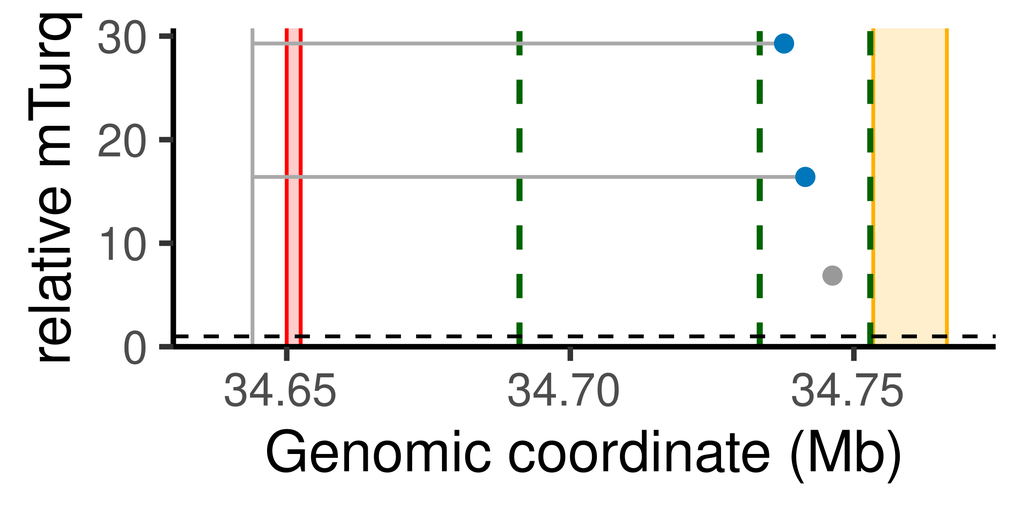

```r
ggplot(filter(expression_tib_cor, sample %in% c('clone_E2221_1-54_34', 'clone_E2221_1-64_34', 'clone_E2221_3-55_34') ),
               aes(x = start, y = rel_norm_mTurq, col = observed_clonetype_mapping,
                   lab = sample)) +
  # annotate enhancer
  annotate("rect", xmin = start(enhancer), xmax = end(enhancer), ymin = -Inf, ymax = Inf, alpha = .2, fill = brown) +
  geom_vline(xintercept = c(start(enhancer), end(enhancer)), col = brown) +
  # annotate gene
  annotate("rect", xmin = start(Sox2_gene), xmax = end(Sox2_gene), ymin = -Inf, ymax = Inf, alpha = .2, fill = red) +
  geom_vline(xintercept = c(start(Sox2_gene), end(Sox2_gene)), col = red) +
  #annotate landing pad
  geom_vline(xintercept = start(landingPad_23), col = 'darkgrey') +

  #annotate SNPs
  geom_vline(xintercept = c(34691039, 34733400, 34752890), col = 'darkgreen', linewidth = 0.8, lty = 'dashed') +

  #indicate scaled expression of 1 (23_34A)
  geom_hline(yintercept = 1, linetype = 'dashed')+

  #layout
  labs(x='Genomic coordinate (Mb)', y = 'relative mTurq') +
  theme_classic(base_size = 16) +
  theme(legend.position = "none") +
  scale_x_continuous(breaks = scales::pretty_breaks(n = 4),
                     labels = scales::unit_format(scale = 1E-6, accuracy = 0.01, unit=NULL),
                     limits=c(34.63E6, 34.775E6),
                     expand = c(0,0)
                     ) +
  scale_y_continuous(limits=c(0,NA),
                     expand = expansion(mult = c(0,0.05))) +

  #points
  geom_segment(data = filter(expression_tib_cor, sample %in% c('clone_E2221_1-54_34', 'clone_E2221_1-64_34')),
               aes(x = start_del, xend = end_del, yend = rel_norm_mTurq), col  = 'darkgrey')+
  geom_point(size = 2) +

  colScale_ins_del
```